# Image Preprocessing, Data Augmentation, CNN and Transfer Learning

### Defining the model architecture

```python
from keras.models import Sequential
from keras.layers import Dense, Dropout, Flatten
from keras.layers import Conv2D, MaxPooling2D
```

Declaring a sequential model

```python
model = Sequential()
```

###### 2D convolution layer (e.g. spatial convolution over images).

```
keras.layers.Conv2D(filters, kernel_size, strides=(1, 1), padding='valid', data_format=None, dilation_rate=(1, 1), activation=None, use_bias=True, kernel_initializer='glorot_uniform', bias_initializer='zeros', kernel_regularizer=None, bias_regularizer=None, activity_regularizer=None, kernel_constraint=None, bias_constraint=None)
```

This layer creates a convolution kernel that is convolved with the layer input to produce a tensor of outputs. The first required Conv2D parameter is the number of filters that the convolutional layer will learn.

Layers early in the network architecture (i.e., closer to the actual input image) learn fewer convolutional filters while layers deeper in the network (i.e., closer to the output predictions) will learn more filters.

```python
model.add(Conv2D(32, (3, 3), activation='relu', input_shape=input_shape))
model.add(MaxPooling2D(pool_size=(2, 2)))
model.add(Dropout(0.2))
```

[output not shown]

###### Add more layers to our model

Activation

```
The activation  parameter to the Conv2D class is a parameter, allowing us to supply a string specifying the name of the activation function we
want to apply after performing the convolution.
```

Dropout

```
This is a method for regularizing our model in order to prevent overfitting. The effect is that the network becomes less sensitive to the specific weights of neurons. This in turn results in a network that is capable of better generalization and is less likely to overfit the training data.
```

MaxPooling2D

```
Is a way to reduce the number of parameters in our model by sliding a 2x2 pooling filter across the previous layer and taking the max of the 4 values in the 2x2 filter.
```

As our output spatial volume is decreasing our number of filters learned is increasing — this is a common practice in designing CNN architectures. Choosing the appropriate number of filters recommended using powers of 2 as the values.

The second parameter to the Keras Conv2D class is the kernel_size.Typical values for kernel_size include: (1, 1) , (3, 3) , (5, 5) , (7, 7). If your input images are greater than 128×128 we may choose to use a kernel size > 3 to help (1) learn larger spatial filters and (2) to help reduce volume size.

```python
model.add(Conv2D(64, (3, 3), activation='relu'))
model.add(MaxPooling2D(pool_size=(2, 2)))
model.add(Dropout(0.2))

#model.add(Conv2D(128, (3, 3), activation='relu'))
#model.add(MaxPooling2D(pool_size=(2, 2)))
#model.add(Dropout(0.2))
```

So far, for model parameters, we've added two Convolution layers. To complete our model architecture, let's add a fully connected layer and then the output layer.

For Dense layers, the first parameter is the output size of the layer. Keras automatically handles the connections between layers.

Note that the final layer has an output size of 10, corresponding to the 10 classes of images.

Also note that the weights from the Convolution layers must be flattened (made 1-dimensional) before passing them to the fully connected Dense layer.

```python
model.add(Flatten())
model.add(Dense(64, activation='relu'))
model.add(Dropout(0.2))
model.add(Dense(num_classes, activation='softmax'))
```

### Compile the model

Compile the model by providing the loss function and the optimizer

```python
model.compile(loss='categorical_crossentropy', optimizer='adam', metrics=["accuracy"])
```

### Model Summary

```python
model.summary()
```

```
_________________________________________________________________
Layer (type)                 Output Shape              Param #
=================================================================
conv2d_1 (Conv2D)            (None, 222, 222, 32)      896
_________________________________________________________________
max_pooling2d_1 (MaxPooling2 (None, 111, 111, 32)      0
_________________________________________________________________
dropout_1 (Dropout)          (None, 111, 111, 32)      0
_________________________________________________________________
conv2d_2 (Conv2D)            (None, 109, 109, 64)      18496
_________________________________________________________________
max_pooling2d_2 (MaxPooling2 (None, 54, 54, 64)        0
_________________________________________________________________
dropout_2 (Dropout)          (None, 54, 54, 64)        0
_________________________________________________________________
flatten_1 (Flatten)          (None, 186624)            0
_________________________________________________________________
dense_1 (Dense)              (None, 64)                11944000
_________________________________________________________________
dropout_3 (Dropout)          (None, 64)                0
_________________________________________________________________
dense_2 (Dense)              (None, 10)                650
=================================================================
Total params: 11,964,042
Trainable params: 11,964,042
Non-trainable params: 0
_________________________________________________________________
```

### Training/fit the model

```python
num_epoch = 10
batch_size = 32

hist = model.fit(X_train, y_train, batch_size = batch_size,
                 epochs = num_epoch, verbose = 1,
                 validation_data = (X_validate, y_validate))
```

```
Train on 2980 samples, validate on 745 samples
```

#### Evaluating the model

```python
score = model.evaluate(X_validate, y_validate, batch_size=batch_size)

print('Test Loss:', score[0])
print('Test Accuracy:', score[1])
```

```
Test Loss: 0.30358241441528366
Test Accuracy: 0.9234899328859061
```

## Test Data Prediction

```python
img_data_list=[]

img_list = os.listdir(os.path.join(PATH, 'test_data'))

for img in img_list:
    test_img = test_img = cv2.imread(os.path.join(PATH, 'test_data') + '/' + 'test_image.jpg')
    test_img_resize = cv2.resize(test_img,(img_rows, img_cols))
    img_data_list.append(test_img_resize)
```

```python
import numpy as np

test_data = np.array(img_data_list)
test_data = test_data.astype('float32')
test_data /= 255
```

```python
print (test_data.shape)
```

```
(1, 224, 224, 3)
```

```python
np.set_printoptions(suppress=True)
print(model.predict(test_data))
print(model.predict_classes(test_data))
print('The image belongs to ' + classes_names_list[int(model.predict_classes(test_data))])
```

```
[[0.00000148 0.9999205  0.00000001 0.00000001 0.00003647 0.00000001
  0.0000402  0.00000006 0.00000007 0.00000136]]
[1]
The image belongs to BACKGROUND_Google
```

# Transfer Learning

##### VGG Architecture

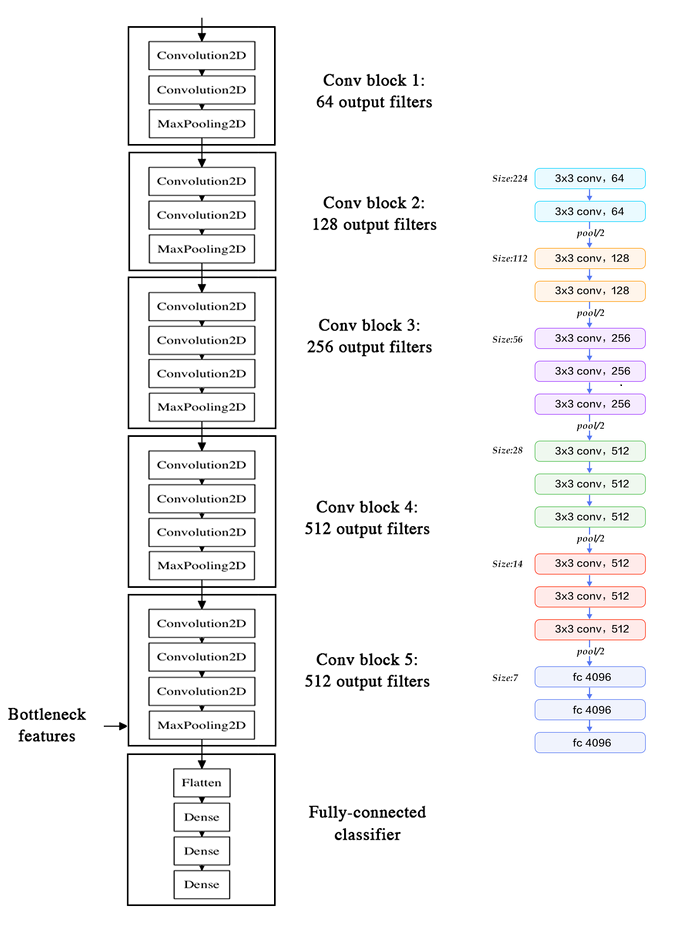

```python
from IPython.display import Image
Image(filename='img/vgg16.png')
```

```python
from keras.layers import Input, Dense
```

```python
#Training the classifier alone
num_channel = 3

image_input = Input(shape=(img_rows, img_cols, num_channel))
```

```python
from keras.applications.vgg16 import VGG16

model = VGG16(input_tensor=image_input, include_top=True, weights='imagenet')
```

```python
model.summary()
```

```
_________________________________________________________________
Layer (type)                 Output Shape              Param #
=================================================================
input_1 (InputLayer)         (None, 224, 224, 3)       0
_________________________________________________________________
block1_conv1 (Conv2D)        (None, 224, 224, 64)      1792
_________________________________________________________________
block1_conv2 (Conv2D)        (None, 224, 224, 64)      36928
_________________________________________________________________
block1_pool (MaxPooling2D)   (None, 112, 112, 64)      0
_________________________________________________________________
block2_conv1 (Conv2D)        (None, 112, 112, 128)     73856
_________________________________________________________________
block2_conv2 (Conv2D)        (None, 112, 112, 128)     147584
_________________________________________________________________
block2_pool (MaxPooling2D)   (None, 56, 56, 128)       0
_________________________________________________________________
block3_conv1 (Conv2D)        (None, 56, 56, 256)       295168
_________________________________________________________________
block3_conv2 (Conv2D)        (None, 56, 56, 256)       590080
_________________________________________________________________
block3_conv3 (Conv2D)        (None, 56, 56, 256)       590080
_________________________________________________________________
block3_pool (MaxPooling2D)   (None, 28, 28, 256)       0
_________________________________________________________________
block4_conv1 (Conv2D)        (None, 28, 28, 512)       1180160
_________________________________________________________________
block4_conv2 (Conv2D)        (None, 28, 28, 512)       2359808
_________________________________________________________________
block4_conv3 (Conv2D)        (None, 28, 28, 512)       2359808
_________________________________________________________________
block4_pool (MaxPooling2D)   (None, 14, 14, 512)       0
_________________________________________________________________
block5_conv1 (Conv2D)        (None, 14, 14, 512)       2359808
_________________________________________________________________
block5_conv2 (Conv2D)        (None, 14, 14, 512)       2359808
_________________________________________________________________
block5_conv3 (Conv2D)        (None, 14, 14, 512)       2359808
_________________________________________________________________
block5_pool (MaxPooling2D)   (None, 7, 7, 512)         0
_________________________________________________________________
flatten (Flatten)            (None, 25088)             0
_________________________________________________________________
fc1 (Dense)                  (None, 4096)              102764544
_________________________________________________________________
fc2 (Dense)                  (None, 4096)              16781312
_________________________________________________________________
predictions (Dense)          (None, 1000)              4097000
=================================================================
Total params: 138,357,544
Trainable params: 138,357,544
Non-trainable params: 0
_________________________________________________________________
```

```python
last_layer = model.get_layer('fc2').output
out = Dense(num_classes, activation='softmax', name='output')(last_layer)
```

```python
from keras.models import Model

custom_vgg_model = Model(image_input, out)
custom_vgg_model.summary()
```

```
_________________________________________________________________
Layer (type)                 Output Shape              Param #
=================================================================
input_1 (InputLayer)         (None, 224, 224, 3)       0
_________________________________________________________________
block1_conv1 (Conv2D)        (None, 224, 224, 64)      1792
_________________________________________________________________
block1_conv2 (Conv2D)        (None, 224, 224, 64)      36928
_________________________________________________________________
block1_pool (MaxPooling2D)   (None, 112, 112, 64)      0
_________________________________________________________________
block2_conv1 (Conv2D)        (None, 112, 112, 128)     73856
_________________________________________________________________
block2_conv2 (Conv2D)        (None, 112, 112, 128)     147584
_________________________________________________________________
block2_pool (MaxPooling2D)   (None, 56, 56, 128)       0
_________________________________________________________________
block3_conv1 (Conv2D)        (None, 56, 56, 256)       295168
_________________________________________________________________
block3_conv2 (Conv2D)        (None, 56, 56, 256)       590080
_________________________________________________________________
block3_conv3 (Conv2D)        (None, 56, 56, 256)       590080
_________________________________________________________________
block3_pool (MaxPooling2D)   (None, 28, 28, 256)       0
_________________________________________________________________
block4_conv1 (Conv2D)        (None, 28, 28, 512)       1180160
_________________________________________________________________
block4_conv2 (Conv2D)        (None, 28, 28, 512)       2359808
_________________________________________________________________
block4_conv3 (Conv2D)        (None, 28, 28, 512)       2359808
_________________________________________________________________
block4_pool (MaxPooling2D)   (None, 14, 14, 512)       0
_________________________________________________________________
block5_conv1 (Conv2D)        (None, 14, 14, 512)       2359808
_________________________________________________________________
block5_conv2 (Conv2D)        (None, 14, 14, 512)       2359808
_________________________________________________________________
block5_conv3 (Conv2D)        (None, 14, 14, 512)       2359808
_________________________________________________________________
block5_pool (MaxPooling2D)   (None, 7, 7, 512)         0
_________________________________________________________________
flatten (Flatten)            (None, 25088)             0
_________________________________________________________________
fc1 (Dense)                  (None, 4096)              102764544
_________________________________________________________________
fc2 (Dense)                  (None, 4096)              16781312
_________________________________________________________________
output (Dense)               (None, 10)                40970
=================================================================
Total params: 134,301,514
Trainable params: 134,301,514
Non-trainable params: 0
_________________________________________________________________
```

```python
for layer in custom_vgg_model.layers[:-1]:
    layer.trainable = False
```

```python
custom_vgg_model.compile(loss='categorical_crossentropy', optimizer='rmsprop', metrics=['accuracy'])
```

```python
batch_size = 32
custom_vgg_model.fit(X_train, y_train, batch_size=batch_size, epochs=10, verbose=1,
                     validation_data=(X_validate, y_validate))
```

```
Train on 2980 samples, validate on 745 samples
```

```
<keras.callbacks.History at 0x25ab31e2940>
```

```python
(loss, accuracy) = custom_vgg_model.evaluate(X_validate, y_validate, batch_size=batch_size, verbose=1)

print("[INFO] loss={:.4f}, accuracy: {:.4f}%".format(loss, accuracy * 100))
```

```
[INFO] loss=0.0491, accuracy: 98.6577%
```

## Test Data Prediction

```python
img_data_list=[]

img_list = os.listdir(os.path.join(PATH, 'test_data'))

for img in img_list:
    test_img = test_img = cv2.imread(os.path.join(PATH, 'test_data') + '/' + 'test_image.jpg')
    test_img_resize = cv2.resize(test_img,(img_rows, img_cols))
    img_data_list.append(test_img_resize)

import numpy as np

test_data = np.array(img_data_list)
test_data = test_data.astype('float32')
test_data /= 255
print (test_data.shape)
```

```
(1, 224, 224, 3)
```

```python
np.set_printoptions(suppress=True)
print(custom_vgg_model.predict(test_data))
Y_test_pred = custom_vgg_model.predict(test_data)
print(np.argmax(Y_test_pred, axis=1))
print('The image belongs to ' + classes_names_list[int(np.argmax(Y_test_pred, axis=1))])
```

```
[[0.00010241 0.8404679  0.00117733 0.         0.00042107 0.00026625
  0.00017702 0.         0.1392025  0.01818561]]
[1]
The image belongs to BACKGROUND_Google
```

###### Transfer Learning - 2

```python
# Training the feature extraction also
model = VGG16(input_tensor=image_input, include_top=True, weights='imagenet')
```

```python
last_layer = model.get_layer('block5_pool').output
x = Flatten(name='flatten')(last_layer)
x = Dense(128, activation='relu', name='fc1')(x)
x = Dense(128, activation='relu', name='fc2')(x)
out = Dense(num_classes, activation='softmax', name='output')(x)
custom_vgg_model2 = Model(image_input, out)
```

```python
custom_vgg_model2.summary()
```

```
_________________________________________________________________
Layer (type)                 Output Shape              Param #
=================================================================
input_1 (InputLayer)         (None, 224, 224, 3)       0
_________________________________________________________________
block1_conv1 (Conv2D)        (None, 224, 224, 64)      1792
_________________________________________________________________
block1_conv2 (Conv2D)        (None, 224, 224, 64)      36928
_________________________________________________________________
block1_pool (MaxPooling2D)   (None, 112, 112, 64)      0
_________________________________________________________________
block2_conv1 (Conv2D)        (None, 112, 112, 128)     73856
_________________________________________________________________
block2_conv2 (Conv2D)        (None, 112, 112, 128)     147584
_________________________________________________________________
block2_pool (MaxPooling2D)   (None, 56, 56, 128)       0
_________________________________________________________________
block3_conv1 (Conv2D)        (None, 56, 56, 256)       295168
_________________________________________________________________
block3_conv2 (Conv2D)        (None, 56, 56, 256)       590080
_________________________________________________________________
block3_conv3 (Conv2D)        (None, 56, 56, 256)       590080
_________________________________________________________________
block3_pool (MaxPooling2D)   (None, 28, 28, 256)       0
_________________________________________________________________
block4_conv1 (Conv2D)        (None, 28, 28, 512)       1180160
_________________________________________________________________
block4_conv2 (Conv2D)        (None, 28, 28, 512)       2359808
_________________________________________________________________
block4_conv3 (Conv2D)        (None, 28, 28, 512)       2359808
_________________________________________________________________
block4_pool (MaxPooling2D)   (None, 14, 14, 512)       0
_________________________________________________________________
block5_conv1 (Conv2D)        (None, 14, 14, 512)       2359808
_________________________________________________________________
block5_conv2 (Conv2D)        (None, 14, 14, 512)       2359808
_________________________________________________________________
block5_conv3 (Conv2D)        (None, 14, 14, 512)       2359808
_________________________________________________________________
block5_pool (MaxPooling2D)   (None, 7, 7, 512)         0
_________________________________________________________________
flatten (Flatten)            (None, 25088)             0
_________________________________________________________________
fc1 (Dense)                  (None, 128)               3211392
_________________________________________________________________
fc2 (Dense)                  (None, 128)               16512
_________________________________________________________________
output (Dense)               (None, 10)                1290
=================================================================
Total params: 17,943,882
Trainable params: 17,943,882
Non-trainable params: 0
_________________________________________________________________
```

```python
# freeze all the layers except the dense layers
for layer in custom_vgg_model2.layers[:-3]:
    layer.trainable = False
```

```python
custom_vgg_model2.summary()
```

```
_________________________________________________________________
Layer (type)                 Output Shape              Param #
=================================================================
input_1 (InputLayer)         (None, 224, 224, 3)       0
_________________________________________________________________
block1_conv1 (Conv2D)        (None, 224, 224, 64)      1792
_________________________________________________________________
block1_conv2 (Conv2D)        (None, 224, 224, 64)      36928
_________________________________________________________________
block1_pool (MaxPooling2D)   (None, 112, 112, 64)      0
_________________________________________________________________
block2_conv1 (Conv2D)        (None, 112, 112, 128)     73856
_________________________________________________________________
block2_conv2 (Conv2D)        (None, 112, 112, 128)     147584
_________________________________________________________________
block2_pool (MaxPooling2D)   (None, 56, 56, 128)       0
_________________________________________________________________
block3_conv1 (Conv2D)        (None, 56, 56, 256)       295168
_________________________________________________________________
block3_conv2 (Conv2D)        (None, 56, 56, 256)       590080
_________________________________________________________________
block3_conv3 (Conv2D)        (None, 56, 56, 256)       590080
_________________________________________________________________
block3_pool (MaxPooling2D)   (None, 28, 28, 256)       0
_________________________________________________________________
block4_conv1 (Conv2D)        (None, 28, 28, 512)       1180160
_________________________________________________________________
block4_conv2 (Conv2D)        (None, 28, 28, 512)       2359808
_________________________________________________________________
block4_conv3 (Conv2D)        (None, 28, 28, 512)       2359808
_________________________________________________________________
block4_pool (MaxPooling2D)   (None, 14, 14, 512)       0
_________________________________________________________________
block5_conv1 (Conv2D)        (None, 14, 14, 512)       2359808
_________________________________________________________________
block5_conv2 (Conv2D)        (None, 14, 14, 512)       2359808
_________________________________________________________________
block5_conv3 (Conv2D)        (None, 14, 14, 512)       2359808
_________________________________________________________________
block5_pool (MaxPooling2D)   (None, 7, 7, 512)         0
_________________________________________________________________
flatten (Flatten)            (None, 25088)             0
_________________________________________________________________
fc1 (Dense)                  (None, 128)               3211392
_________________________________________________________________
fc2 (Dense)                  (None, 128)               16512
_________________________________________________________________
output (Dense)               (None, 10)                1290
=================================================================
Total params: 17,943,882
Trainable params: 3,229,194
Non-trainable params: 14,714,688
_________________________________________________________________
```

```python
custom_vgg_model2.compile(loss='categorical_crossentropy', optimizer='adadelta', metrics=['accuracy'])
```

```python
hist = custom_vgg_model2.fit(X_train, y_train, batch_size=batch_size, epochs=10, verbose=1,
                             validation_data=(X_validate, y_validate))
```

```
Train on 2980 samples, validate on 745 samples
```

```python
(loss, accuracy) = custom_vgg_model2.evaluate(X_validate, y_validate, batch_size=batch_size, verbose=1)

print("[INFO] loss={:.4f}, accuracy: {:.4f}%".format(loss,accuracy * 100))
```

```
[INFO] loss=0.0468, accuracy: 98.6577%
```

## Test Data Prediction

```python
np.set_printoptions(suppress=True)
print(custom_vgg_model2.predict(test_data))
Y_test_pred = custom_vgg_model2.predict(test_data)
print(np.argmax(Y_test_pred, axis=1))
print('The image belongs to ' + classes_names_list[int(np.argmax(Y_test_pred, axis=1))])
```

```
[[0.0000493  0.9781486  0.00000114 0.00001641 0.00000451 0.00003679
  0.01347951 0.00000022 0.0041609  0.0041026 ]]
[1]
The image belongs to BACKGROUND_Google
```